# Module 4 Pair Quiz

John Rollic Conducto and Gian Nicole Villamayor

7/27/2021

## Answers

### **Question 1**

**An article in the Journal of Sound and Vibration [“Measurement of Noise-Evoked Blood Pressure by Means of Averaging Method: Relation between Blood Pressure Rise and PSL” (1991, Vol. 151(3), pp. 383-394)] described a study investigating the relationship between noise exposure and hypertension. The following data are representative of those reported in the article.**

```
##      x y
## 1   60 1
## 2   63 0
## 3   65 1
## 4   70 2
## 5   70 5
## 6   70 1
## 7   80 4
## 8   90 6
## 9   80 2
## 10  80 3
## 11  85 5
## 12  89 4
## 13  90 6
## 14  90 8
## 15  90 4
## 16  90 5
## 17  94 7
## 18 100 9
## 19 100 7
## 20 100 6
```

**A. Draw a scatter diagram of y (blood pressure rise in millimeters of mercury) versus x (sound pressure level in decibels). Does a simple linear regression model seem reasonable in this situation?**

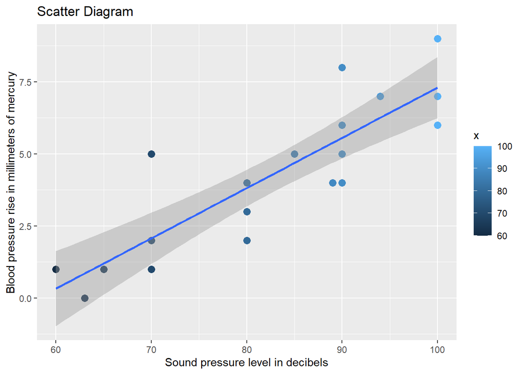

**The simple linear regression model seem reasonable in this situation because the dependent variable (y) and the independent variable (x) forms a linear relation and increasing trend which means that the scattered points form a straight line.**

**B. Fit the simple linear regression model using least squares. Find an estimate of $\sigma ^2$.**

A simple linear regression model is denoted by:  
$Y=B_0+B_1x+\epsilon$  
By applying the method of least squares, we can estimate the $B_0$ which is the intercept and $B_1$ which is the slope.  
These are some formulas that we will be using to find the equation of the linear regression:  
$\beta _1=\frac{S_{xy}}{S_{xx}}$  
$\beta _0=\bar{y}-\beta _1x$  
$S_{xx}=\sum \left(x_i-\bar{x}\right)^2$  
$S_{xy}=\sum \:y_i\left(x_i-\bar{x}\right)^2$  
Let’s create a table for the data:

```
##    x_values y_values x_minus_mean x_minus_mean_squared x_mins_mean_squared_x_y
## 1        60        1        -22.8               519.84                   -22.8
## 2        63        0        -19.8               392.04                     0.0
## 3        65        1        -17.8               316.84                   -17.8
## 4        70        2        -12.8               163.84                   -25.6
## 5        70        5        -12.8               163.84                   -64.0
## 6        70        1        -12.8               163.84                   -12.8
## 7        80        4         -2.8                 7.84                   -11.2
## 8        90        6          7.2                51.84                    43.2
## 9        80        2         -2.8                 7.84                    -5.6
## 10       80        3         -2.8                 7.84                    -8.4
## 11       85        5          2.2                 4.84                    11.0
## 12       89        4          6.2                38.44                    24.8
## 13       90        6          7.2                51.84                    43.2
## 14       90        8          7.2                51.84                    57.6
## 15       90        4          7.2                51.84                    28.8
## 16       90        5          7.2                51.84                    36.0
## 17       94        7         11.2               125.44                    78.4
## 18      100        9         17.2               295.84                   154.8
## 19      100        7         17.2               295.84                   120.4
## 20      100        6         17.2               295.84                   103.2
```

$\sum \:y_i\left(x_i-\bar{x}\right)^2=533.2$  
$\sum \left(x_i-\bar{x}\right)^2=3059.2$

Solution for the equation of linear regression: $\beta _1=\frac{S_{xy}}{S_{xx}}$

```
##    y_values y_minus_mean y_minus_mean_squared
## 1         1         -3.3                10.89
## 2         0         -4.3                18.49
## 3         1         -3.3                10.89
## 4         2         -2.3                 5.29
## 5         5          0.7                 0.49
## 6         1         -3.3                10.89
## 7         4         -0.3                 0.09
## 8         6          1.7                 2.89
## 9         2         -2.3                 5.29
## 10        3         -1.3                 1.69
## 11        5          0.7                 0.49
## 12        4         -0.3                 0.09
## 13        6          1.7                 2.89
## 14        8          3.7                13.69
## 15        4         -0.3                 0.09
## 16        5          0.7                 0.49
## 17        7          2.7                 7.29
## 18        9          4.7                22.09
## 19        7          2.7                 7.29
## 20        6          1.7                 2.89
```

**C. Find the predicted mean rise in blood pressure level associated with a sound pressure level of 85 decibels.**

Based on the previous item, the equation of the linear regression for this problem is represented by: $Y=-10.132+0.1743x$, wherein x is the *sound pressure level in decibels* and y is the *blood pressure rise in millimeters of mercury*. Therefore, we need to substitute 85 decibels as the value of x.

We will then have:  
$Y=-10.132+0.1743\left(85\right)$  
$Y=-10.132+14.82$  
**$Y=4.68$ mm**  
**Therefore, the predicted mean rise in blood pressure level associated with a sound pressure level of 85 decibels is 4.68 mm.**

### **Question 2**

**An article in Optical Engineering [“Operating Curve Extraction of a Correlator’s Filter” (2004, Vol. 43, pp. 2775-2779)] reported on the use of an optical correlator to perform an experiment by varying brightness and contrast. The resulting modulation is characterized by the useful range of gray levels. The data follow:**

```
##   Brightness_percent Contrast_percent Useful_range
## 1                 54               56           96
## 2                 61               80           50
## 3                 65               70           50
## 4                100               50          112
## 5                100               65           96
## 6                100               80           80
## 7                 50               25          155
## 8                 57               35          144
## 9                 54               26          255
```

### **References**

[1] D. Montgomery and G. Runger, Applied statistics and probability for engineers, 7th ed. Wiley, 2017, pp. 262–279.  
[2] E. Yihui Xie, “7.6 Put content in tabs | R Markdown Cookbook”, Bookdown.org. [Online]. Available: https://bookdown.org/yihui/rmarkdown-cookbook/html-tabs.html. [Accessed: 30- Jul- 2021].  
[3] R. Cunningham, “First Fun with RMarkdown,” RPubs. [Online]. Available: https://rpubs.com/redrobincl/241336. [Accessed: 29-Jul-2021].